# Risk Factor Analysis

## Outcome Variable

**Outcome Variable:** pers_wasted624

## Predictor Variables

**Intervention Variable:** ever_wasted06

**Adjustment Set:**

- sex
- arm
- enstunt
- month
- brthmon
- vagbrth
- single
- W_gagebrth
- W_birthwt
- W_birthlen
- W_mage
- W_mhtcm
- W_meducyrs
- W_feducyrs
- W_parity
- delta_month
- delta_brthmon
- delta_vagbrth
- delta_single
- delta_W_gagebrth
- delta_W_birthwt
- delta_W_birthlen
- delta_W_mage
- delta_W_mhtcm
- delta_W_meducyrs
- delta_W_feducyrs
- delta_W_parity

## Stratifying Variables

The analysis was stratified on these variable(s):

- studyid
- country

## Data Summary

| studyid | country | ever_wasted06 | pers_wasted624 | n_cell | n |
| --- | --- | --- | --- | --- | --- |
| ki0047075b-MAL-ED | BANGLADESH | 0 | 0 | 180 | 239 |
| ki0047075b-MAL-ED | BANGLADESH | 0 | 1 | 5 | 239 |
| ki0047075b-MAL-ED | BANGLADESH | 1 | 0 | 41 | 239 |
| ki0047075b-MAL-ED | BANGLADESH | 1 | 1 | 13 | 239 |
| ki0047075b-MAL-ED | BRAZIL | 0 | 0 | 187 | 202 |
| ki0047075b-MAL-ED | BRAZIL | 0 | 1 | 1 | 202 |
| ki0047075b-MAL-ED | BRAZIL | 1 | 0 | 13 | 202 |
| ki0047075b-MAL-ED | BRAZIL | 1 | 1 | 1 | 202 |
| ki0047075b-MAL-ED | INDIA | 0 | 0 | 154 | 234 |
| ki0047075b-MAL-ED | INDIA | 0 | 1 | 6 | 234 |
| ki0047075b-MAL-ED | INDIA | 1 | 0 | 52 | 234 |
| ki0047075b-MAL-ED | INDIA | 1 | 1 | 22 | 234 |
| ki0047075b-MAL-ED | NEPAL | 0 | 0 | 194 | 234 |
| ki0047075b-MAL-ED | NEPAL | 0 | 1 | 0 | 234 |
| ki0047075b-MAL-ED | NEPAL | 1 | 0 | 38 | 234 |
| ki0047075b-MAL-ED | NEPAL | 1 | 1 | 2 | 234 |
| ki0047075b-MAL-ED | PERU | 0 | 0 | 252 | 264 |
| ki0047075b-MAL-ED | PERU | 0 | 1 | 2 | 264 |
| ki0047075b-MAL-ED | PERU | 1 | 0 | 10 | 264 |
| ki0047075b-MAL-ED | PERU | 1 | 1 | 0 | 264 |
| ki0047075b-MAL-ED | SOUTH AFRICA | 0 | 0 | 232 | 258 |
| ki0047075b-MAL-ED | SOUTH AFRICA | 0 | 1 | 0 | 258 |
| ki0047075b-MAL-ED | SOUTH AFRICA | 1 | 0 | 24 | 258 |
| ki0047075b-MAL-ED | SOUTH AFRICA | 1 | 1 | 2 | 258 |
| ki0047075b-MAL-ED | TANZANIA, UNITED REPUBLIC OF | 0 | 0 | 233 | 244 |
| ki0047075b-MAL-ED | TANZANIA, UNITED REPUBLIC OF | 0 | 1 | 0 | 244 |
| ki0047075b-MAL-ED | TANZANIA, UNITED REPUBLIC OF | 1 | 0 | 11 | 244 |
| ki0047075b-MAL-ED | TANZANIA, UNITED REPUBLIC OF | 1 | 1 | 0 | 244 |
| ki1000108-CMC-V-BCS-2002 | INDIA | 0 | 0 | 174 | 368 |
| ki1000108-CMC-V-BCS-2002 | INDIA | 0 | 1 | 3 | 368 |

[output cut: 118 more lines]

The following strata were considered:

- studyid: ki0047075b-MAL-ED, country: BANGLADESH
- studyid: ki0047075b-MAL-ED, country: BRAZIL
- studyid: ki0047075b-MAL-ED, country: INDIA
- studyid: ki0047075b-MAL-ED, country: NEPAL
- studyid: ki0047075b-MAL-ED, country: PERU
- studyid: ki0047075b-MAL-ED, country: SOUTH AFRICA
- studyid: ki0047075b-MAL-ED, country: TANZANIA, UNITED REPUBLIC OF
- studyid: ki1000108-CMC-V-BCS-2002, country: INDIA
- studyid: ki1000108-IRC, country: INDIA
- studyid: ki1000109-EE, country: PAKISTAN
- studyid: ki1000109-ResPak, country: PAKISTAN
- studyid: ki1000304-VITAMIN-A, country: INDIA
- studyid: ki1000304b-SAS-CompFeed, country: INDIA
- studyid: ki1000304b-SAS-FoodSuppl, country: INDIA
- studyid: ki1017093-NIH-Birth, country: BANGLADESH
- studyid: ki1017093b-PROVIDE, country: BANGLADESH
- studyid: ki1017093c-NIH-Crypto, country: BANGLADESH
- studyid: ki1066203-TanzaniaChild2, country: TANZANIA, UNITED REPUBLIC OF
- studyid: ki1101329-Keneba, country: GAMBIA
- studyid: ki1112895-Burkina Faso Zn, country: BURKINA FASO
- studyid: ki1112895-Guatemala BSC, country: GUATEMALA
- studyid: ki1113344-GMS-Nepal, country: NEPAL
- studyid: ki1114097-CMIN, country: BANGLADESH
- studyid: ki1114097-CMIN, country: BRAZIL
- studyid: ki1114097-CMIN, country: GUINEA-BISSAU
- studyid: ki1114097-CMIN, country: PERU
- studyid: ki1114097-CONTENT, country: PERU
- studyid: ki1119695-PROBIT, country: BELARUS
- studyid: ki1126311-ZVITAMBO, country: ZIMBABWE
- studyid: ki1135781-COHORTS, country: GUATEMALA
- studyid: ki1135781-COHORTS, country: INDIA
- studyid: ki1135781-COHORTS, country: PHILIPPINES
- studyid: ki1148112-iLiNS-DOSE, country: MALAWI
- studyid: ki1148112-iLiNS-DYAD-M, country: MALAWI
- studyid: ki1148112-LCNI-5, country: MALAWI
- studyid: kiGH5241-JiVitA-3, country: BANGLADESH
- studyid: kiGH5241-JiVitA-4, country: BANGLADESH

### Dropped Strata

Some strata were dropped due to rare outcomes:

- studyid: ki0047075b-MAL-ED, country: BRAZIL
- studyid: ki0047075b-MAL-ED, country: NEPAL
- studyid: ki0047075b-MAL-ED, country: PERU
- studyid: ki0047075b-MAL-ED, country: SOUTH AFRICA
- studyid: ki0047075b-MAL-ED, country: TANZANIA, UNITED REPUBLIC OF
- studyid: ki1000108-CMC-V-BCS-2002, country: INDIA
- studyid: ki1112895-Burkina Faso Zn, country: BURKINA FASO
- studyid: ki1112895-Guatemala BSC, country: GUATEMALA
- studyid: ki1114097-CMIN, country: BRAZIL
- studyid: ki1114097-CMIN, country: PERU
- studyid: ki1114097-CONTENT, country: PERU
- studyid: ki1148112-iLiNS-DOSE, country: MALAWI
- studyid: ki1148112-iLiNS-DYAD-M, country: MALAWI
- studyid: ki1148112-LCNI-5, country: MALAWI

## Methods Detail

We’re interested in the causal parameters $E[Y_a]$ for all values of $a \in \mathcal{A}$. These parameters represent the mean outcome if, possibly contrary to fact, we intervened to set all units to have $A=a$. Under the randomization and positivity assumptions, these are identified by the statistical parameters $\psi_a=E_W[E_{Y|A,W}(Y|A=a,W)]$. In addition, we’re interested in the mean of $Y$, $E[Y]$ under no intervention (the observed mean). We will estimate these parameters by using SuperLearner to fit the relevant likelihood factors – $E_{Y|A,W}(Y|A=a,W)$ and $p(A=a|W)$, and then updating our likelihood fit using a joint TMLE.

For unadjusted analyses ($W=\{\}$), initial likelihoods were estimated using Lrnr_glm to estimate the simple $E(Y|A)$ and Lrnr_mean to estimate $p(A)$. For adjusted analyses, a small library containing Lrnr_glmnet, Lrnr_xgboost, and Lrnr_mean was used.

Having estimated these parameters, we will then use the delta method to estimate relative risks and attributable risks relative to a prespecified baseline level of $A$.

# Results Detail

## Results Plots

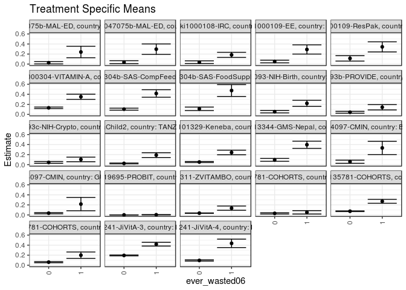

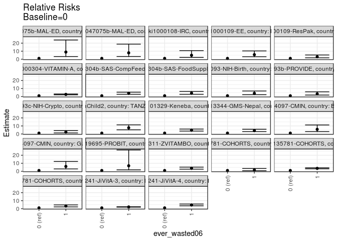

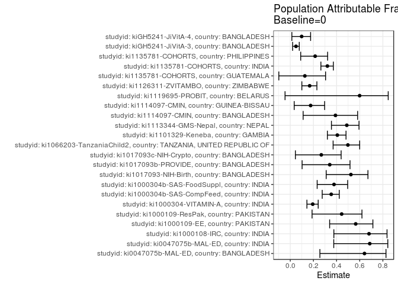

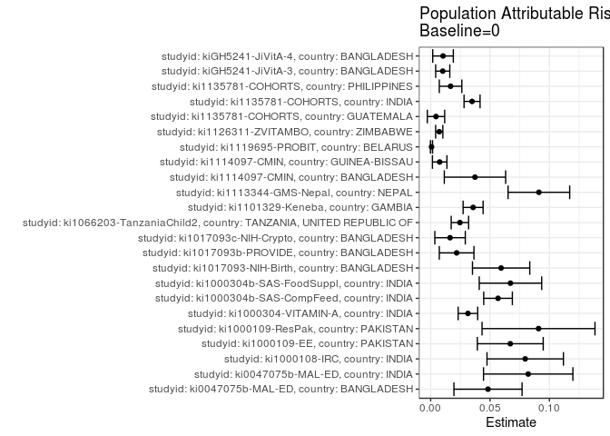

## Results Table

### Parameter: TSM

| studyid | country | intervention_level | baseline_level | estimate | ci_lower | ci_upper |
| --- | --- | --- | --- | --- | --- | --- |
| ki0047075b-MAL-ED | BANGLADESH | 0 | NA | 0.0270270 | 0.0036105 | 0.0504435 |
| ki0047075b-MAL-ED | BANGLADESH | 1 | NA | 0.2407407 | 0.1264709 | 0.3550106 |
| ki0047075b-MAL-ED | INDIA | 0 | NA | 0.0375000 | 0.0079992 | 0.0670008 |
| ki0047075b-MAL-ED | INDIA | 1 | NA | 0.2972973 | 0.1929350 | 0.4016596 |
| ki1000108-IRC | INDIA | 0 | NA | 0.0374332 | 0.0101935 | 0.0646728 |
| ki1000108-IRC | INDIA | 1 | NA | 0.1838565 | 0.1329529 | 0.2347601 |
| ki1000109-EE | PAKISTAN | 0 | NA | 0.0515407 | 0.0250890 | 0.0779923 |
| ki1000109-EE | PAKISTAN | 1 | NA | 0.2910359 | 0.1995172 | 0.3825546 |
| ki1000109-ResPak | PAKISTAN | 0 | NA | 0.1136965 | 0.0595857 | 0.1678073 |
| ki1000109-ResPak | PAKISTAN | 1 | NA | 0.3429832 | 0.2422927 | 0.4436737 |
| ki1000304-VITAMIN-A | INDIA | 0 | NA | 0.1303536 | 0.1155086 | 0.1451986 |
| ki1000304-VITAMIN-A | INDIA | 1 | NA | 0.3505856 | 0.2986481 | 0.4025232 |
| ki1000304b-SAS-CompFeed | INDIA | 0 | NA | 0.1036082 | 0.0833916 | 0.1238248 |
| ki1000304b-SAS-CompFeed | INDIA | 1 | NA | 0.4163459 | 0.3416636 | 0.4910282 |
| ki1000304b-SAS-FoodSuppl | INDIA | 0 | NA | 0.1106175 | 0.0760394 | 0.1451955 |
| ki1000304b-SAS-FoodSuppl | INDIA | 1 | NA | 0.4751562 | 0.3568549 | 0.5934575 |
| ki1017093-NIH-Birth | BANGLADESH | 0 | NA | 0.0539382 | 0.0296118 | 0.0782646 |
| ki1017093-NIH-Birth | BANGLADESH | 1 | NA | 0.2196438 | 0.1593534 | 0.2799342 |
| ki1017093b-PROVIDE | BANGLADESH | 0 | NA | 0.0422734 | 0.0238363 | 0.0607104 |
| ki1017093b-PROVIDE | BANGLADESH | 1 | NA | 0.1417730 | 0.0887624 | 0.1947835 |
| ki1017093c-NIH-Crypto | BANGLADESH | 0 | NA | 0.0446014 | 0.0272171 | 0.0619856 |
| ki1017093c-NIH-Crypto | BANGLADESH | 1 | NA | 0.1041939 | 0.0585039 | 0.1498839 |
| ki1066203-TanzaniaChild2 | TANZANIA, UNITED REPUBLIC OF | 0 | NA | 0.0248286 | 0.0172978 | 0.0323594 |
| ki1066203-TanzaniaChild2 | TANZANIA, UNITED REPUBLIC OF | 1 | NA | 0.1899846 | 0.1424098 | 0.2375593 |
| ki1101329-Keneba | GAMBIA | 0 | NA | 0.0521622 | 0.0420332 | 0.0622912 |
| ki1101329-Keneba | GAMBIA | 1 | NA | 0.2425757 | 0.1967324 | 0.2884189 |
| ki1113344-GMS-Nepal | NEPAL | 0 | NA | 0.0954904 | 0.0672230 | 0.1237578 |
| ki1113344-GMS-Nepal | NEPAL | 1 | NA | 0.3964317 | 0.3246140 | 0.4682494 |
| ki1114097-CMIN | BANGLADESH | 0 | NA | 0.0582902 | 0.0266071 | 0.0899733 |
| ki1114097-CMIN | BANGLADESH | 1 | NA | 0.3332842 | 0.2011190 | 0.4654494 |
| ki1114097-CMIN | GUINEA-BISSAU | 0 | NA | 0.0356295 | 0.0231019 | 0.0481570 |
| ki1114097-CMIN | GUINEA-BISSAU | 1 | NA | 0.2162162 | 0.0834961 | 0.3489363 |
| ki1119695-PROBIT | BELARUS | 0 | NA | 0.0004875 | 0.0000008 | 0.0009742 |
| ki1119695-PROBIT | BELARUS | 1 | NA | 0.0033800 | 0.0000091 | 0.0067509 |
| ki1126311-ZVITAMBO | ZIMBABWE | 0 | NA | 0.0359738 | 0.0318539 | 0.0400936 |
| ki1126311-ZVITAMBO | ZIMBABWE | 1 | NA | 0.1353794 | 0.0935356 | 0.1772232 |
| ki1135781-COHORTS | GUATEMALA | 0 | NA | 0.0311751 | 0.0183597 | 0.0439905 |
| ki1135781-COHORTS | GUATEMALA | 1 | NA | 0.0521790 | 0.0187967 | 0.0855612 |
| ki1135781-COHORTS | INDIA | 0 | NA | 0.0739006 | 0.0665997 | 0.0812015 |
| ki1135781-COHORTS | INDIA | 1 | NA | 0.2715811 | 0.2326774 | 0.3104849 |
| ki1135781-COHORTS | PHILIPPINES | 0 | NA | 0.0612434 | 0.0498508 | 0.0726360 |
| ki1135781-COHORTS | PHILIPPINES | 1 | NA | 0.2002408 | 0.1369209 | 0.2635606 |
| kiGH5241-JiVitA-3 | BANGLADESH | 0 | NA | 0.1954805 | 0.1865299 | 0.2044311 |
| kiGH5241-JiVitA-3 | BANGLADESH | 1 | NA | 0.4191880 | 0.3818873 | 0.4564887 |
| kiGH5241-JiVitA-4 | BANGLADESH | 0 | NA | 0.0954587 | 0.0827352 | 0.1081821 |
| kiGH5241-JiVitA-4 | BANGLADESH | 1 | NA | 0.4362161 | 0.3517288 | 0.5207034 |

### Parameter: E(Y)

| studyid | country | intervention_level | baseline_level | estimate | ci_lower | ci_upper |
| --- | --- | --- | --- | --- | --- | --- |
| ki0047075b-MAL-ED | BANGLADESH | NA | NA | 0.0753138 | 0.0417869 | 0.1088408 |
| ki0047075b-MAL-ED | INDIA | NA | NA | 0.1196581 | 0.0779840 | 0.1613323 |
| ki1000108-IRC | INDIA | NA | NA | 0.1170732 | 0.0859146 | 0.1482317 |
| ki1000109-EE | PAKISTAN | NA | NA | 0.1185984 | 0.0856546 | 0.1515422 |
| ki1000109-ResPak | PAKISTAN | NA | NA | 0.2045455 | 0.1511224 | 0.2579685 |
| ki1000304-VITAMIN-A | INDIA | NA | NA | 0.1617391 | 0.1466878 | 0.1767905 |
| ki1000304b-SAS-CompFeed | INDIA | NA | NA | 0.1603563 | 0.1395035 | 0.1812092 |
| ki1000304b-SAS-FoodSuppl | INDIA | NA | NA | 0.1778351 | 0.1397389 | 0.2159312 |
| ki1017093-NIH-Birth | BANGLADESH | NA | NA | 0.1132813 | 0.0858017 | 0.1407608 |
| ki1017093b-PROVIDE | BANGLADESH | NA | NA | 0.0641447 | 0.0446535 | 0.0836359 |
| ki1017093c-NIH-Crypto | BANGLADESH | NA | NA | 0.0609418 | 0.0434802 | 0.0784034 |
| ki1066203-TanzaniaChild2 | TANZANIA, UNITED REPUBLIC OF | NA | NA | 0.0494534 | 0.0397554 | 0.0591514 |
| ki1101329-Keneba | GAMBIA | NA | NA | 0.0879121 | 0.0760335 | 0.0997907 |
| ki1113344-GMS-Nepal | NEPAL | NA | NA | 0.1866438 | 0.1550166 | 0.2182711 |
| ki1114097-CMIN | BANGLADESH | NA | NA | 0.0956175 | 0.0591654 | 0.1320697 |
| ki1114097-CMIN | GUINEA-BISSAU | NA | NA | 0.0432309 | 0.0297785 | 0.0566834 |
| ki1119695-PROBIT | BELARUS | NA | NA | 0.0012159 | 0.0002433 | 0.0021885 |
| ki1126311-ZVITAMBO | ZIMBABWE | NA | NA | 0.0432128 | 0.0388939 | 0.0475316 |
| ki1135781-COHORTS | GUATEMALA | NA | NA | 0.0356745 | 0.0235298 | 0.0478191 |
| ki1135781-COHORTS | INDIA | NA | NA | 0.1087695 | 0.1008135 | 0.1167256 |
| ki1135781-COHORTS | PHILIPPINES | NA | NA | 0.0780116 | 0.0679971 | 0.0880261 |
| kiGH5241-JiVitA-3 | BANGLADESH | NA | NA | 0.2056528 | 0.1980793 | 0.2132263 |
| kiGH5241-JiVitA-4 | BANGLADESH | NA | NA | 0.1058706 | 0.0951082 | 0.1166330 |

### Parameter: RR

| studyid | country | intervention_level | baseline_level | estimate | ci_lower | ci_upper |
| --- | --- | --- | --- | --- | --- | --- |
| ki0047075b-MAL-ED | BANGLADESH | 0 | 0 | 1.000000 | 1.0000000 | 1.000000 |
| ki0047075b-MAL-ED | BANGLADESH | 1 | 0 | 8.907407 | 3.3167043 | 23.921912 |
| ki0047075b-MAL-ED | INDIA | 0 | 0 | 1.000000 | 1.0000000 | 1.000000 |
| ki0047075b-MAL-ED | INDIA | 1 | 0 | 7.927928 | 3.3499192 | 18.762256 |
| ki1000108-IRC | INDIA | 0 | 0 | 1.000000 | 1.0000000 | 1.000000 |
| ki1000108-IRC | INDIA | 1 | 0 | 4.911595 | 2.2547088 | 10.699283 |
| ki1000109-EE | PAKISTAN | 0 | 0 | 1.000000 | 1.0000000 | 1.000000 |
| ki1000109-EE | PAKISTAN | 1 | 0 | 5.646722 | 3.0888146 | 10.322883 |
| ki1000109-ResPak | PAKISTAN | 0 | 0 | 1.000000 | 1.0000000 | 1.000000 |
| ki1000109-ResPak | PAKISTAN | 1 | 0 | 3.016657 | 1.7234143 | 5.280344 |
| ki1000304-VITAMIN-A | INDIA | 0 | 0 | 1.000000 | 1.0000000 | 1.000000 |
| ki1000304-VITAMIN-A | INDIA | 1 | 0 | 2.689498 | 2.2324019 | 3.240186 |
| ki1000304b-SAS-CompFeed | INDIA | 0 | 0 | 1.000000 | 1.0000000 | 1.000000 |
| ki1000304b-SAS-CompFeed | INDIA | 1 | 0 | 4.018466 | 2.9245363 | 5.521583 |
| ki1000304b-SAS-FoodSuppl | INDIA | 0 | 0 | 1.000000 | 1.0000000 | 1.000000 |
| ki1000304b-SAS-FoodSuppl | INDIA | 1 | 0 | 4.295490 | 2.8786952 | 6.409582 |
| ki1017093-NIH-Birth | BANGLADESH | 0 | 0 | 1.000000 | 1.0000000 | 1.000000 |
| ki1017093-NIH-Birth | BANGLADESH | 1 | 0 | 4.072139 | 2.3984236 | 6.913839 |
| ki1017093b-PROVIDE | BANGLADESH | 0 | 0 | 1.000000 | 1.0000000 | 1.000000 |
| ki1017093b-PROVIDE | BANGLADESH | 1 | 0 | 3.353718 | 1.8872409 | 5.959718 |
| ki1017093c-NIH-Crypto | BANGLADESH | 0 | 0 | 1.000000 | 1.0000000 | 1.000000 |
| ki1017093c-NIH-Crypto | BANGLADESH | 1 | 0 | 2.336114 | 1.2994843 | 4.199689 |
| ki1066203-TanzaniaChild2 | TANZANIA, UNITED REPUBLIC OF | 0 | 0 | 1.000000 | 1.0000000 | 1.000000 |
| ki1066203-TanzaniaChild2 | TANZANIA, UNITED REPUBLIC OF | 1 | 0 | 7.651853 | 5.1627050 | 11.341121 |
| ki1101329-Keneba | GAMBIA | 0 | 0 | 1.000000 | 1.0000000 | 1.000000 |
| ki1101329-Keneba | GAMBIA | 1 | 0 | 4.650409 | 3.5503243 | 6.091361 |
| ki1113344-GMS-Nepal | NEPAL | 0 | 0 | 1.000000 | 1.0000000 | 1.000000 |
| ki1113344-GMS-Nepal | NEPAL | 1 | 0 | 4.151534 | 2.9370845 | 5.868144 |
| ki1114097-CMIN | BANGLADESH | 0 | 0 | 1.000000 | 1.0000000 | 1.000000 |
| ki1114097-CMIN | BANGLADESH | 1 | 0 | 5.717674 | 2.9189800 | 11.199731 |
| ki1114097-CMIN | GUINEA-BISSAU | 0 | 0 | 1.000000 | 1.0000000 | 1.000000 |
| ki1114097-CMIN | GUINEA-BISSAU | 1 | 0 | 6.068468 | 2.9912946 | 12.311161 |
| ki1119695-PROBIT | BELARUS | 0 | 0 | 1.000000 | 1.0000000 | 1.000000 |
| ki1119695-PROBIT | BELARUS | 1 | 0 | 6.932963 | 1.8068114 | 26.602654 |
| ki1126311-ZVITAMBO | ZIMBABWE | 0 | 0 | 1.000000 | 1.0000000 | 1.000000 |
| ki1126311-ZVITAMBO | ZIMBABWE | 1 | 0 | 3.763283 | 2.7065156 | 5.232668 |
| ki1135781-COHORTS | GUATEMALA | 0 | 0 | 1.000000 | 1.0000000 | 1.000000 |
| ki1135781-COHORTS | GUATEMALA | 1 | 0 | 1.673740 | 0.7824782 | 3.580172 |
| ki1135781-COHORTS | INDIA | 0 | 0 | 1.000000 | 1.0000000 | 1.000000 |
| ki1135781-COHORTS | INDIA | 1 | 0 | 3.674951 | 3.0900772 | 4.370528 |
| ki1135781-COHORTS | PHILIPPINES | 0 | 0 | 1.000000 | 1.0000000 | 1.000000 |
| ki1135781-COHORTS | PHILIPPINES | 1 | 0 | 3.269589 | 2.2676183 | 4.714291 |
| kiGH5241-JiVitA-3 | BANGLADESH | 0 | 0 | 1.000000 | 1.0000000 | 1.000000 |
| kiGH5241-JiVitA-3 | BANGLADESH | 1 | 0 | 2.144398 | 1.9440423 | 2.365403 |
| kiGH5241-JiVitA-4 | BANGLADESH | 0 | 0 | 1.000000 | 1.0000000 | 1.000000 |
| kiGH5241-JiVitA-4 | BANGLADESH | 1 | 0 | 4.569685 | 3.6144576 | 5.777360 |

### Parameter: PAR

| studyid | country | intervention_level | baseline_level | estimate | ci_lower | ci_upper |
| --- | --- | --- | --- | --- | --- | --- |
| ki0047075b-MAL-ED | BANGLADESH | 0 | NA | 0.0482868 | 0.0195900 | 0.0769836 |
| ki0047075b-MAL-ED | INDIA | 0 | NA | 0.0821581 | 0.0445166 | 0.1197996 |
| ki1000108-IRC | INDIA | 0 | NA | 0.0796400 | 0.0474529 | 0.1118271 |
| ki1000109-EE | PAKISTAN | 0 | NA | 0.0670577 | 0.0393155 | 0.0947999 |
| ki1000109-ResPak | PAKISTAN | 0 | NA | 0.0908490 | 0.0432929 | 0.1384051 |
| ki1000304-VITAMIN-A | INDIA | 0 | NA | 0.0313856 | 0.0231429 | 0.0396282 |
| ki1000304b-SAS-CompFeed | INDIA | 0 | NA | 0.0567482 | 0.0446869 | 0.0688095 |
| ki1000304b-SAS-FoodSuppl | INDIA | 0 | NA | 0.0672176 | 0.0409076 | 0.0935276 |
| ki1017093-NIH-Birth | BANGLADESH | 0 | NA | 0.0593431 | 0.0352167 | 0.0834694 |
| ki1017093b-PROVIDE | BANGLADESH | 0 | NA | 0.0218714 | 0.0072832 | 0.0364595 |
| ki1017093c-NIH-Crypto | BANGLADESH | 0 | NA | 0.0163405 | 0.0035114 | 0.0291695 |
| ki1066203-TanzaniaChild2 | TANZANIA, UNITED REPUBLIC OF | 0 | NA | 0.0246248 | 0.0172978 | 0.0319519 |
| ki1101329-Keneba | GAMBIA | 0 | NA | 0.0357499 | 0.0273297 | 0.0441700 |
| ki1113344-GMS-Nepal | NEPAL | 0 | NA | 0.0911534 | 0.0652042 | 0.1171026 |
| ki1114097-CMIN | BANGLADESH | 0 | NA | 0.0373274 | 0.0114830 | 0.0631717 |
| ki1114097-CMIN | GUINEA-BISSAU | 0 | NA | 0.0076015 | 0.0014989 | 0.0137041 |
| ki1119695-PROBIT | BELARUS | 0 | NA | 0.0007284 | -0.0001416 | 0.0015983 |
| ki1126311-ZVITAMBO | ZIMBABWE | 0 | NA | 0.0072390 | 0.0042130 | 0.0102650 |
| ki1135781-COHORTS | GUATEMALA | 0 | NA | 0.0044994 | -0.0028013 | 0.0118001 |
| ki1135781-COHORTS | INDIA | 0 | NA | 0.0348689 | 0.0281241 | 0.0416138 |
| ki1135781-COHORTS | PHILIPPINES | 0 | NA | 0.0167682 | 0.0072672 | 0.0262692 |
| kiGH5241-JiVitA-3 | BANGLADESH | 0 | NA | 0.0101723 | 0.0042258 | 0.0161189 |
| kiGH5241-JiVitA-4 | BANGLADESH | 0 | NA | 0.0104120 | 0.0017461 | 0.0190778 |

### Parameter: PAF

| studyid | country | intervention_level | baseline_level | estimate | ci_lower | ci_upper |
| --- | --- | --- | --- | --- | --- | --- |
| ki0047075b-MAL-ED | BANGLADESH | 0 | NA | 0.6411411 | 0.2558997 | 0.8269324 |
| ki0047075b-MAL-ED | INDIA | 0 | NA | 0.6866071 | 0.3757083 | 0.8426776 |
| ki1000108-IRC | INDIA | 0 | NA | 0.6802585 | 0.3765411 | 0.8360202 |
| ki1000109-EE | PAKISTAN | 0 | NA | 0.5654184 | 0.3401246 | 0.7137926 |
| ki1000109-ResPak | PAKISTAN | 0 | NA | 0.4441506 | 0.1883234 | 0.6193453 |
| ki1000304-VITAMIN-A | INDIA | 0 | NA | 0.1940504 | 0.1438288 | 0.2413262 |
| ki1000304b-SAS-CompFeed | INDIA | 0 | NA | 0.3538879 | 0.2759583 | 0.4234299 |
| ki1000304b-SAS-FoodSuppl | INDIA | 0 | NA | 0.3779771 | 0.2323761 | 0.4959609 |
| ki1017093-NIH-Birth | BANGLADESH | 0 | NA | 0.5238560 | 0.3105036 | 0.6711902 |
| ki1017093b-PROVIDE | BANGLADESH | 0 | NA | 0.3409689 | 0.1022300 | 0.5162214 |
| ki1017093c-NIH-Crypto | BANGLADESH | 0 | NA | 0.2681323 | 0.0442966 | 0.4395433 |
| ki1066203-TanzaniaChild2 | TANZANIA, UNITED REPUBLIC OF | 0 | NA | 0.4979402 | 0.3701914 | 0.5997768 |
| ki1101329-Keneba | GAMBIA | 0 | NA | 0.4066548 | 0.3207512 | 0.4816943 |
| ki1113344-GMS-Nepal | NEPAL | 0 | NA | 0.4883816 | 0.3557024 | 0.5937384 |
| ki1114097-CMIN | BANGLADESH | 0 | NA | 0.3903819 | 0.1112654 | 0.5818389 |
| ki1114097-CMIN | GUINEA-BISSAU | 0 | NA | 0.1758345 | 0.0338712 | 0.2969377 |
| ki1119695-PROBIT | BELARUS | 0 | NA | 0.5990331 | -0.0451102 | 0.8461650 |
| ki1126311-ZVITAMBO | ZIMBABWE | 0 | NA | 0.1675203 | 0.1000259 | 0.2299529 |
| ki1135781-COHORTS | GUATEMALA | 0 | NA | 0.1261239 | -0.0989325 | 0.3050897 |
| ki1135781-COHORTS | INDIA | 0 | NA | 0.3205763 | 0.2646174 | 0.3722770 |
| ki1135781-COHORTS | PHILIPPINES | 0 | NA | 0.2149450 | 0.0899775 | 0.3227515 |
| kiGH5241-JiVitA-3 | BANGLADESH | 0 | NA | 0.0494636 | 0.0203082 | 0.0777514 |
| kiGH5241-JiVitA-4 | BANGLADESH | 0 | NA | 0.0983462 | 0.0137040 | 0.1757245 |